# Modelaje Epidemiológico en `R`

Modelos 1: Regresiones

Rodrigo Zepeda & Rossana Torres

2019-07-24

# Distribuciones de probabilidad

Vamos a considerar la siguiente base de datos (que no son normales):

```r
n         <- 20
mis.datos <- data.frame(x = rexp(n))
```

Dichos datos podemos ajustarlos con un histograma:

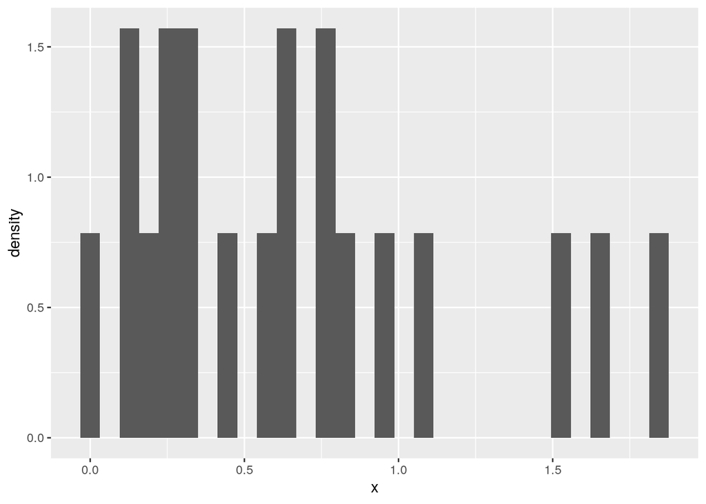

```r
ggplot(mis.datos) +
  geom_histogram(aes(x = x, y = ..density..))
```

Podemos repetir el proceso con cada vez más datos:

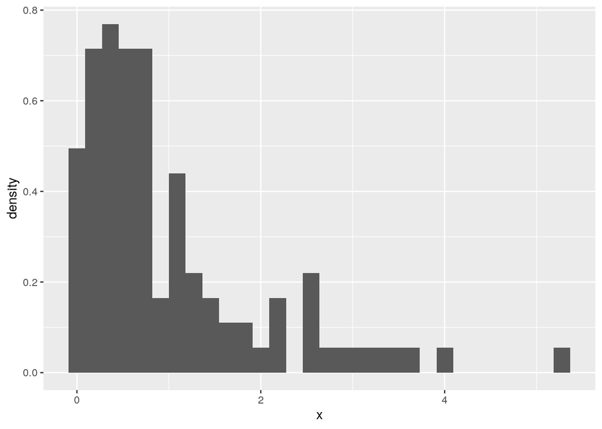

```r
n         <- 100
mis.datos <- data.frame(x = rexp(n))
ggplot(mis.datos) +
  geom_histogram(aes(x = x, y = ..density..))
```

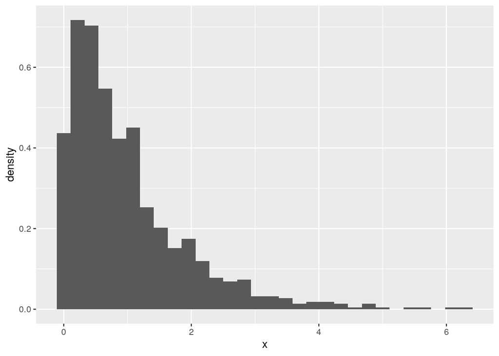

```r
n         <- 1000
mis.datos <- data.frame(x = rexp(n))
ggplot(mis.datos) +
  geom_histogram(aes(x = x, y = ..density..))
```

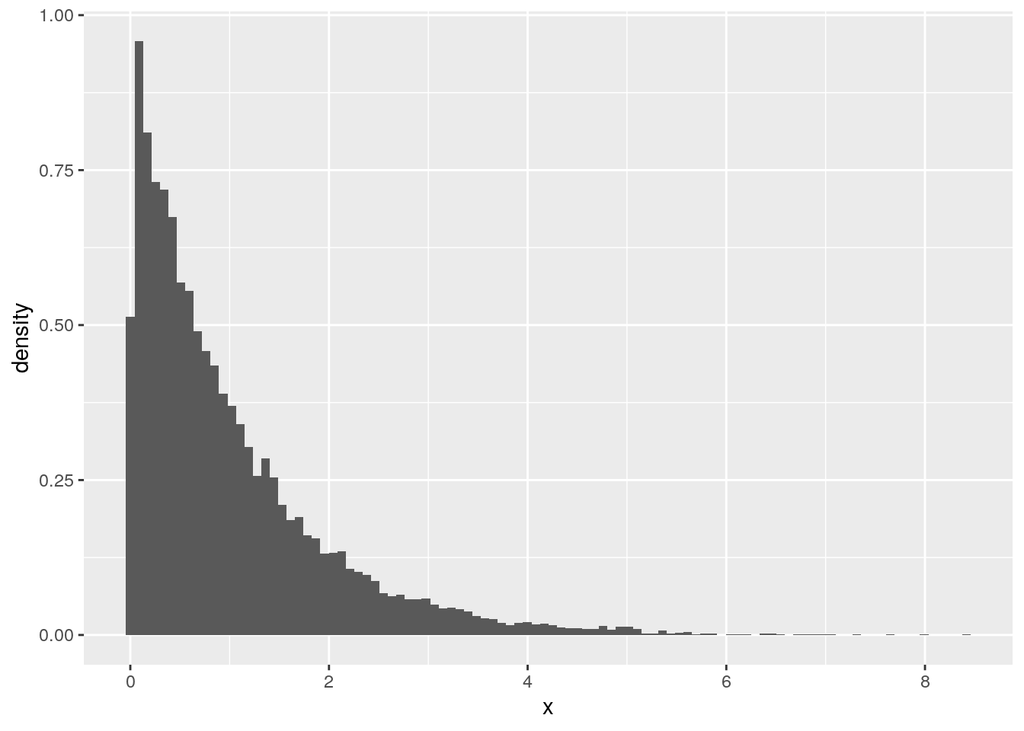

```r
n         <- 10000
mis.datos <- data.frame(x = rexp(n))
ggplot(mis.datos) +
  geom_histogram(aes(x = x, y = ..density..), bins = 100)
```

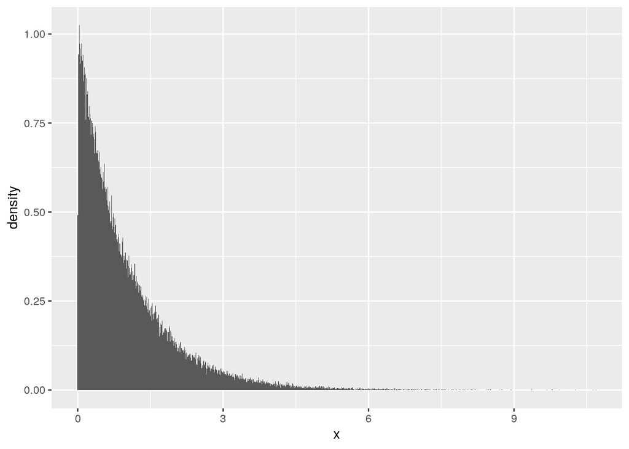

```r
n         <- 100000
mis.datos <- data.frame(x = rexp(n))
ggplot(mis.datos) +
  geom_histogram(aes(x = x, y = ..density..), bins = 1000)
```

Conforme aumentamos la cantidad de datos que tenemos y aumentamos la cantidad de barras (`bins`) que ajustamos esto semeja una curva. De hecho la curva a la que se acerca es una [distribución exponencial](https://en.wikipedia.org/wiki/Exponential_distribution) que podemos graficar con `dexp`:

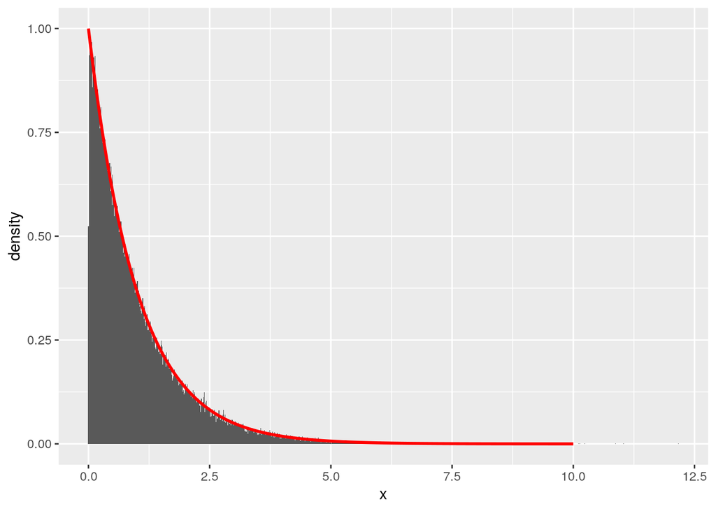

```r
n         <- 100000
x         <- seq(0, 10, length.out = 1000)
mis.datos <- data.frame(x = rexp(n))
mi.dist   <- data.frame(x = x, y = dexp(x))
ggplot(mis.datos) +
  geom_histogram(aes(x = x, y = ..density..), bins = 1000) +
  geom_line(aes(x = x, y = y), data = mi.dist, color = "red", size = 1)
```

Podemos pensar una distribución de probabilidad como un histograma con ancho de barras *infinitamente pequeño*. Ejemplos de distribuciones hay muchos: puede ser la normal, la gamma, la lognormal, la exponencial, la beta, etc:

En términos prácticos en la computadora algo no es infinitamente pequeño ¿recuerdas? sino sólo lo suficiente para que la memoria de la computadora diga ¡hasta aquí!

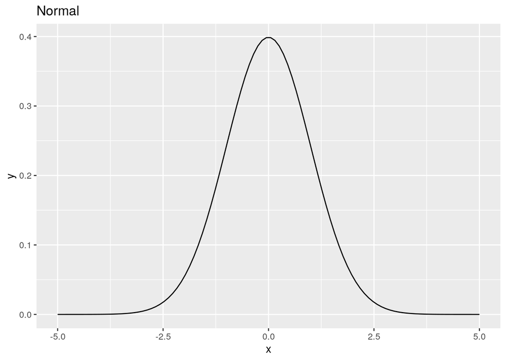

```r
#Distribución normal
x <- seq(-5, 5, length.out = 100)
mis.datos <- data.frame(x = x, y = dnorm(x))
ggplot(mis.datos) + geom_line(aes(x = x, y = y)) +
  ggtitle("Normal")
```

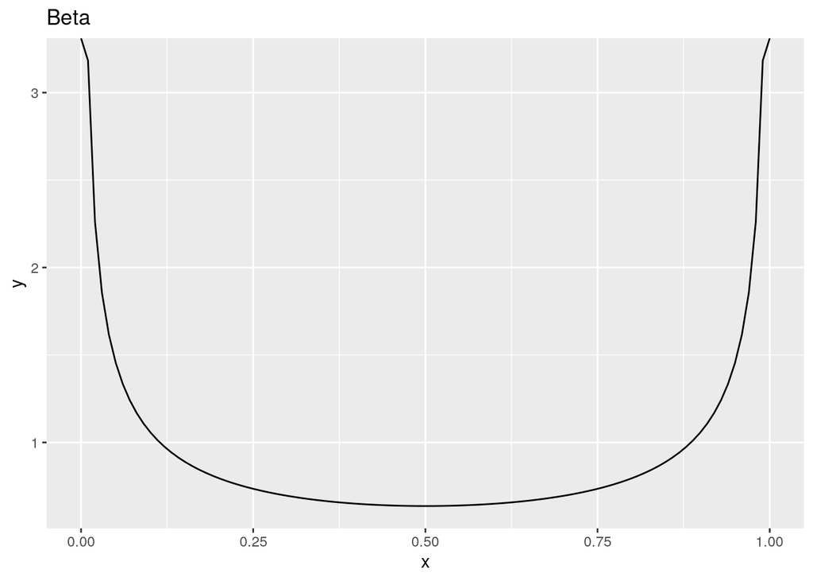

```r
#Distribución beta
x <- seq(0, 1, length.out = 100)
mis.datos <- data.frame(x = x, y = dbeta(x, 0.5, 0.5))
ggplot(mis.datos) + geom_line(aes(x = x, y = y)) +
  ggtitle("Beta")
```

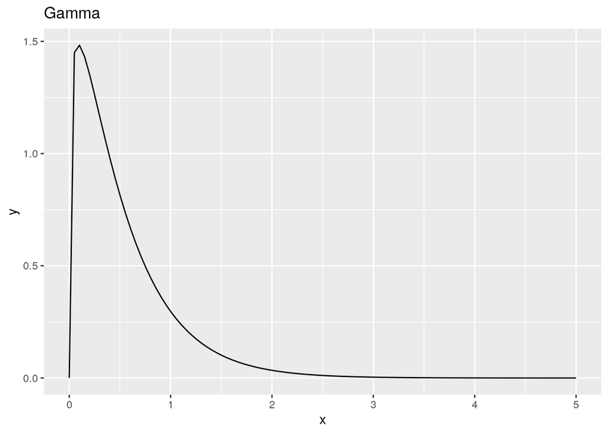

```r
#Distribución gamma
x <- seq(0, 5, length.out = 100)
mis.datos <- data.frame(x = x, y = dgamma(x, 1.2, 2.3))
ggplot(mis.datos) + geom_line(aes(x = x, y = y)) +
  ggtitle("Gamma")
```

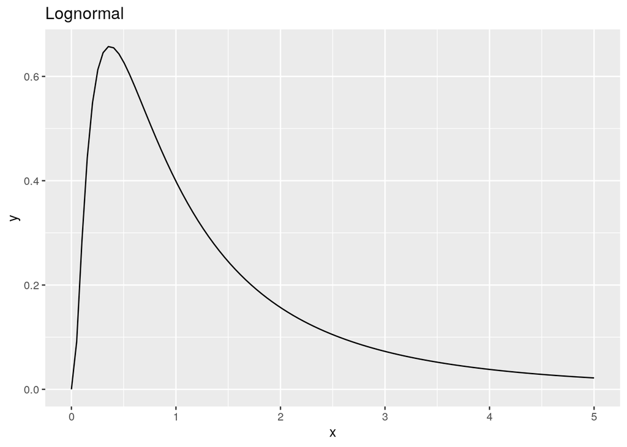

```r
#Distribución normal
x <- seq(0, 5, length.out = 100)
mis.datos <- data.frame(x = x, y = dlnorm(x))
ggplot(mis.datos) + geom_line(aes(x = x, y = y)) +
  ggtitle("Lognormal")
```

Para simular datos de cada una de las distribuciones podemos usar los comandos `rnorm`, `rgamma`, `rlnorm`, etc. Por ejemplo, veamos datos simulados de una gamma:

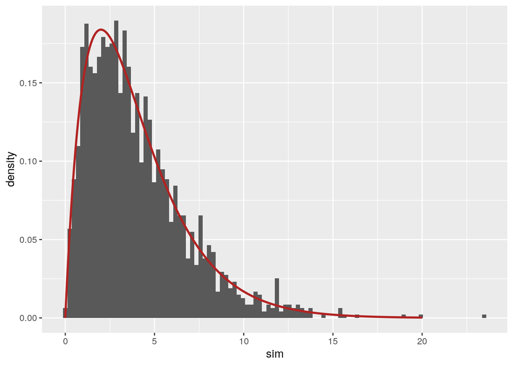

```r
x <- seq(0, 20, length.out = 250)
mi.densidad   <- data.frame(x = x, y = dgamma(x, 2, 1/2))
mi.simulacion <- data.frame(sim = rgamma(2000, 2, 1/2))
ggplot(mi.densidad) +
  geom_histogram(aes(x = sim, y = ..density..), data = mi.simulacion,
                 bins = 100) +
  geom_line(aes(x = x, y = y), color = "firebrick", size = 1)
```

Nota que en general las distribuciones tienen más variables que se conocen como parámetros. En una normal los parámetros son `mu` ($\mu$) y `sigma` ($\sigma$) correspondientes a media y varianza. En general los parámetros están relacionados con la media y la varianza pero significan otras cosas. Por ejemplo para la gamma, los parámetros corresponden a tiempo promedio de ocurrencia de eventos independientes (por ejemplo defunciones por cáncer) y la tasa de ocurrencia del evento. En general el planteamiento matemático del modelo involucra cálculo por lo que es un planteamiento mucho más complejo.